# Data Structure & Algorithm (2)

이 문서는 다양한 알고리즘에 대해 정리한 문서이다. 복습용으로 만든 문서이므로 내용이 틀릴 가능성도 있다…

MIT OpenCourseWare에 있는 [MIT 6.006 Introduction to Algorithms](https://ocw.mit.edu/courses/electrical-engineering-and-computer-science/6-006-introduction-to-algorithms-fall-2011/) 강의를 수강한 후 작성한 복습용 문서이다.

### 알고리즘 (Algorithm)

컴퓨팅에서 알고리즘은 문제를 효율적으로 처리할 수 있는 명령어들이다. 컴퓨터는 초당 많은 작업들을 처리할 수 있지만 한계가 있다. 그러므로 입력값이 커질수록 어떻게 하면 작업을 효율적으로 처리할 수 있는지 중요해진다.

### Peak Finding (극댓값 찾기)

**1차원 (1D)**

배열 [1, 2, …, $\frac{n}{2}$, …, $n-1$, $n$] (인덱스 값을 배열의 값으로 둠) 있다고 하자. 만약 $\frac{n}{2}$ 위치가 극대값이라 하면 컴퓨터는 1번부터 시작해 $\frac{n}{2}$번까지 비교해가 값을 찾는다. 그러면 극대값이 마지막 $n$ 번째에 있으면 모든 배열을 읽어야 한다. 그러므로 최악의 경우 시간 복잡도는 $\theta(n)$이다. 만약 배열이 크기가 $10^{99}$라고 치면 시간이 엄청 오래 걸릴 것이다. 그럼 더 좋은 방법이 없을까?

Divide-and-Conquer (분할 정복) 알고리즘을 사용해서 풀어보자. 분할 정복 알고리즘은 문제를 두개로 쪼개서 해결하고 나중에 합치는 과정이다. A = [1, 2, …, $\frac{n}{2} - 1$, $\frac{n}{2}$, $\frac{n}{2} + 1$, …, $n-1$, $n$] 배열이 있으면중간값 $frac{n}{2}$를 선택한다. A[$\frac{n}{2}$] $\le$ A[$\frac{n}{2} - 1$]이면 왼쪽 부분인 [1, 2, … $\frac{n}{2} - 1$]에서 극댓값을 찾으면 되고 A[$\frac{n}{2}$] $\le$ A[$\frac{n}{2} + 1$]이면 오른쪽 부분인 [$\frac{n}{2} + 1$, … , $n$] 부분에서 극댓값을 찾으면 된다. 여기서 또 중간값을 찾아 과정을 반복하면 된다. 두 조건을 만족하지 않으면 A[$\frac{n}{2}$] 값이 극댓값이 된다.

**2차원 (2D)**

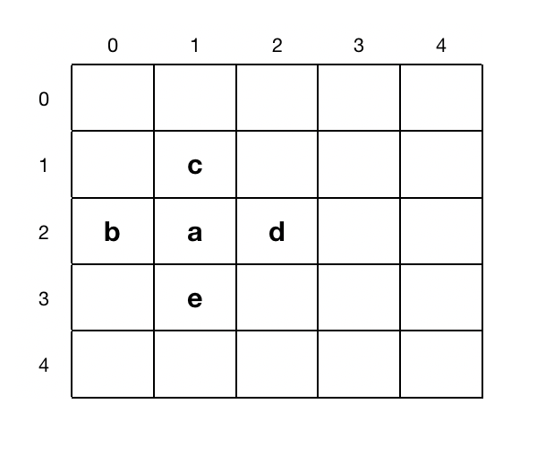

위 그림처럼 2차원 배열(행렬)에서 a가 극댓값이 되러면 $a \ge b$, $a \ge c$, $a \ge d$, $a \ge e$ 조건을 모두 만족해야 한다.

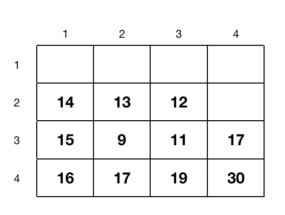

위에 그림에서 극댓값을 찾으려면 Greedy Ascent algorithm을 사용할 수 있다. 먼저 시작점을 고른다. 그리고 위에 조건을 만족하지 않으면 비교하는 값들 중 가장 큰 값이 있는 방향으로 간다. 그리고 극댓값을 구할때까지 이 과정을 반복한다.

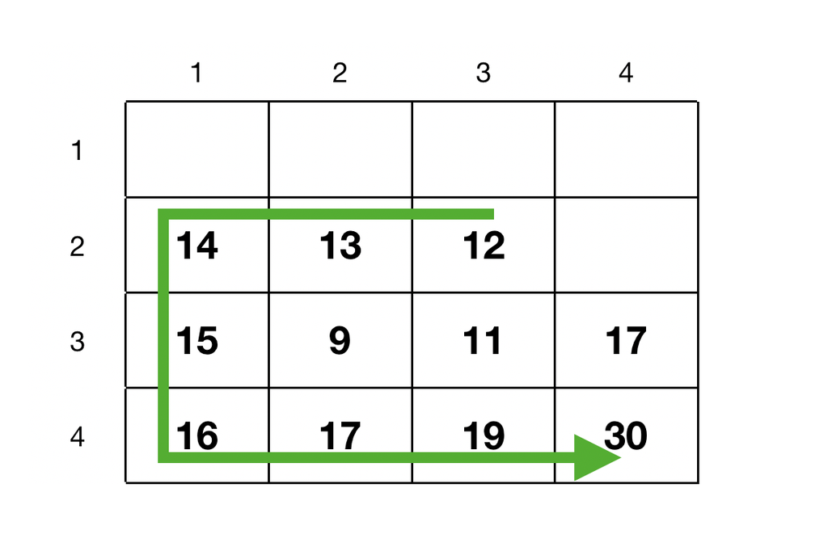

위에 그림에서는 12를 시작점을 두고 시작했다. 왼쪽 13은 12보다 크므로 13으로 이동한 후 그 과정을 계속 반복한다. 그러면 마지막으로 30인 극댓값을 구할 수 있다. 그러나 이 방식은 시작점을 어디에 두는지 처리 시간이 달라진다. 그러나 최악인 경우는 모든 행과 열을 거쳐야한다. 그러면 위 과정의 시간 복잡도는 $\theta(mn)$이 되고 $m=n$이면 $\theta(n^{2})$이 되므로 더 좋은 알고리즘을 알아봐야 할 것이다.

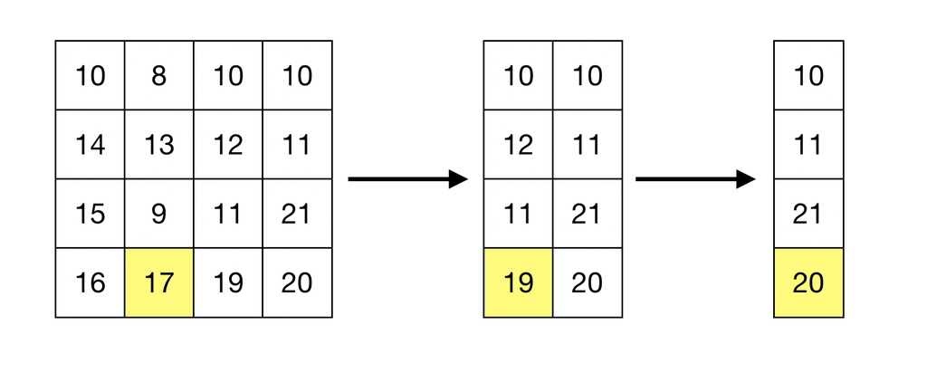

여기서도 분할 정복 알고리즘을 적용해볼 수 있다. 위에 $n$x$m$ 행렬이 있다고 하면 $j = \frac{m}{2}$ 열을 고른다. 그리고 $j$ 열에서 최댓값을 찾는다. 최댓값이 $(i,j)$에 위치해 있다고 하면 $(i,j - 1) > (i,j)$ 이면 왼쪽 부분을 사용하고 $(i,j + 1) > (i,j)$이면 오른쪽 부분을 사용한다. 만약 둘다 조건을 만족하지 않으면 $(i,j)$가 극댓값이 된다.

### Sorting Algorithms (정렬 알고리즘)

문제를 풀려고 할때 순서가 중요할 수도 있다. 정렬에 대한 알고리즘은 많고 문제에 따라 그리고 어떻게 해결할지에 따라 사용되는 알고리즘이 달라진다. 시간을 더 중요시 생각할 수도 있고 아니면 문제를 해결하기 위해 차지하는 메모리 공간을 더 생각할 수 있다. 정확이 이 알고리즘이 좋고 저 알고리즘이 안좋다라고 판정할 수 없다.

#### Insertion Sort (삽입 정렬)

삽입 정렬 방법은 배열의 앞부분 부터 시작해서 차례대로 그 값보다 작은 값들과 비교해서 정렬하는 방식이다.

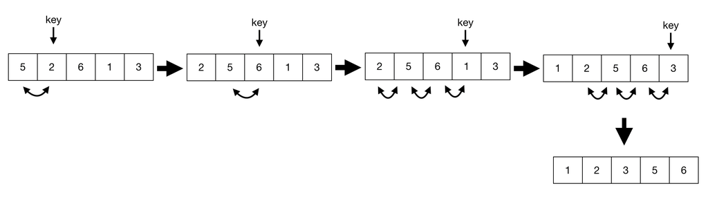

위에 그림을 처럼 $A = [5, 2, 6, 1, 3]$ 배열이 있다고 하자. 삽입 정렬은 $A[i]$의 값을 $A[:i-1]$ 값들과 하나하나씩 비교해 정렬하는 방식이다. 처음에 2에 키값이 있으면 1번 값과 비교한다. 그리고 값이 작으면 바꾼다. 그 다음 키값 6은 5보다 크므로 그대로 두고 다음 단계로 간다. 다음 단계부터 조금 일이 많아진다. 키값이 $A[3] = 1$이고 $A[3] < A[2] = 6$ 이므로 위치를 바꾼다. 여기서 끝난게 아니라 똑같은 과정으로 $A[0]$까지 가야한다. 그럼 이제 $A[2] = 1$이고 $A[1] = 5$와 비교한다. $A[2] < A[1]$이므로 위치를 바꿔줘서 $A[0]$까지 한다. 그리고 이 과정이 끝나면 다음 키값인 $A[4] = 3$을 전에 나온 과정들을 반복한다. 그러면 마지막으로 $A = [1 2, 3, 5, 6]$ 오름차순 배열로 정렬이 된다.

모든 배열의 값들을 확인해야 하므로 시간 복잡도는 $\theta(n)$이다. 그리고 각 키값마다 $\theta(n)$만큼 비교하고 바꾸어야 하니 위에 방법의 삽잉 정렬의 시간 복잡도는 $\theta(n^{2})$이다. 이것보다 좀 더 효율적으로 할 수 있는 방법은 전에는 두개의 짝을 비교했지만 이진 탐색 (binary search) 방법이다. 이것을 이진 삽입 정렬 (binary insertion sort)라기도 한다.

전에는 키값을 전 값들과 하나하나 비교했지만, 이진 탐색을 사용하면 $A[:i-1]$의 중간값 $m$을 찾아 키값을 비교한다. 만약 키값이 중간값보다 크면 $A[m:i-1]$에서 이 과정을 반복하면 되고, 만약 중간값보다 작으면 $A[:m]$에서 위 과정을 반복하면 된다. 이진 탐색은 $\theta(log_{2}{n})$ 시간이 걸리고 $n$개의 값들이 있으니 값을 비교하는 시간 복잡도는 $\theta(nlog_{2}{n})$이다. 그러나 키값의 비교해 삽입할 위치를 찾는건 삽입 정렬 방식보다는 효율적일 수 있으나 이진 탐색을 사용해 삽입하는 시간 복잡도는 $\theta(n^{2})$이다. 왜냐하면 키값을 삽입 할 위치가 중간이면 그에 해당하는 오른쪽 부분을 모두 옮겨야하기 때문이다.

#### Merge Sort (합병 정렬)

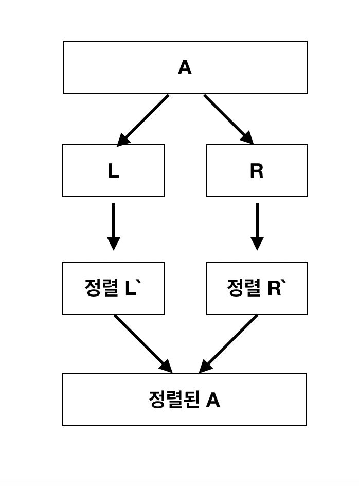

합병 정렬도 분할 정복의 개념이다. $A$ 배열이 있으면 이것을 중간값을 기준으로 두개로 나눈다 ($L$ 배열과 $R$ 배열). 그리고 각 배열을 정렬하고 ($L`$ 배열과 $R`$ 배열) 합쳐 정렬이 된 하나의 배열로 만드는 방법이다.

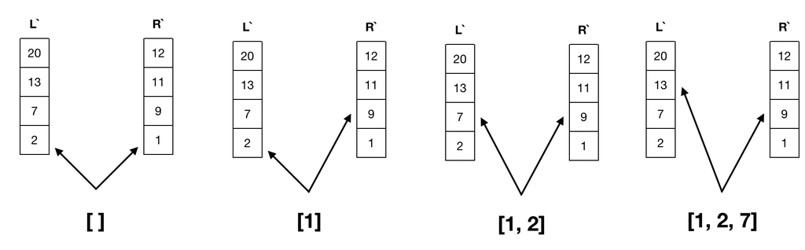

합병 정렬의 시간 복잡도는 $\theta(nlog_{2}{n})$이다. 그 이유는 [페이지 23](https://ocw.mit.edu/courses/electrical-engineering-and-computer-science/6-006-introduction-to-algorithms-fall-2011/lecture-videos/MIT6_006F11_lec03.pdf) 강의 노트를 통해 확인하면 된다. 삽입 정렬보다는 효율적이나 공간 측면에서는 합병 정렬보다 삽입 정렬이 효율적일 수 있다. 합병 정렬은 기존 배열을 나누에 새로 정렬된 배열로 만드는 것이므로 메모리 공간은 삽입 정렬(옆값을 비교해 바꾸므로 일정하다) 에 비해 많이 차지한다.

#### Heap Sort (힙 정렬)

힙 정렬을 힙 자료구조에서 보여 주었듯이 max heap을 만든 후 정렬하는 과정이다.

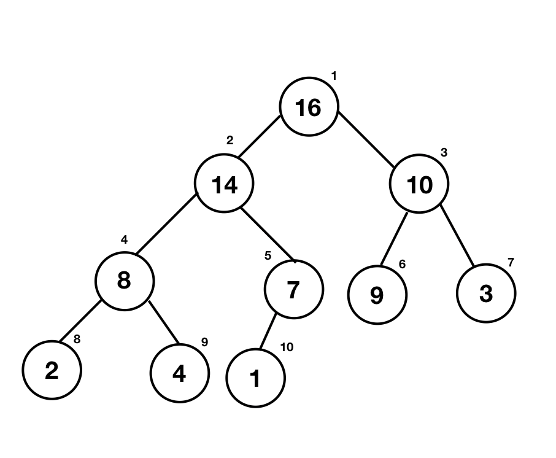

위에 그림은 max heap이며 $A = [16, 14, 10, 8, 7, 9, 3, 2, 4, 1]$이라고 하면 힙 정렬은 1번째 $A[0]$와 배열의 마지막 값 $A[n]$과 바꾼다. 그러면 $A[0]$ -> $A[n]$ 이고 $A[n]$ -> $A[0]$이 되면 $A[n]$을 따로 빼서 새로운 배열에 놓는다. 이 과정을 모든 $A$ 배열 값들이 없어질 때까지 한다.

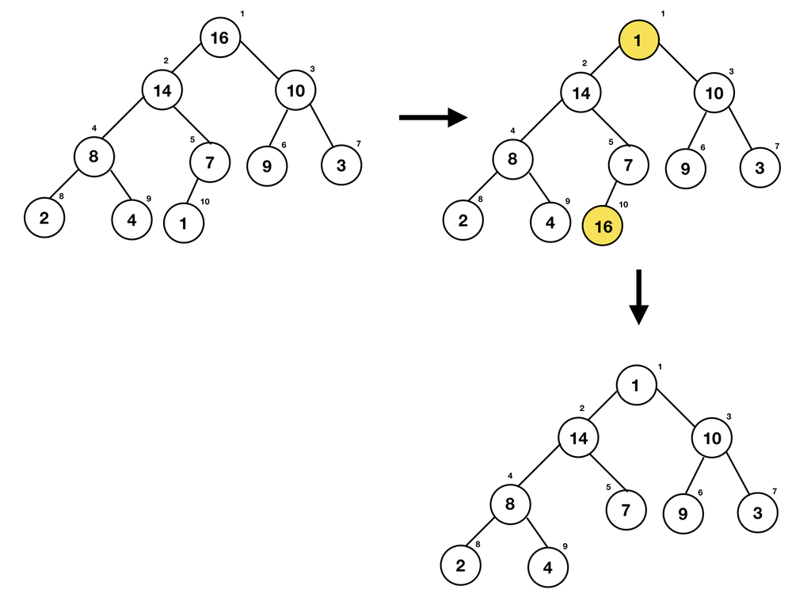

위에 그림처럼 1번째 값과 마지막인 10번째 값을 바꾼 후 이 값을 빼서 $A` = [16]$ 배열에 넣는다.

[figure not shown]

이제 트리를 max heap을 만들어야 하므로 루트 노드값인 1을 자식 노드와 비교한 후 가장 큰 값이랑 바꾼다. 이 과정을 전체 트리가 max heap가 될떄가지 한다. 그러면 위에 그림의 마지막 트리처럼 나올 것이다.

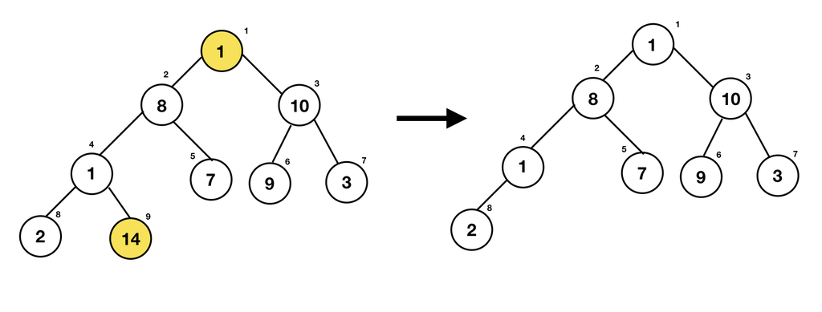

위에 그림은 max heap 이므로 첫번깨 값과 마지막 값을 바꿔서 $A`$ 값에 넣는다. 그러면 $A` = [16, 14]$가 될 것이고 이제 루트 노드값이 1이므로 다시 max heap으로 만들어야 한다. 위에 과정을 $A`$가 모두 채워질때까지 반복한다.

#### Counting Sort (계수 정렬)

이제 선형시간으로 정렬하는 계수 정렬에 대해 알아보겠다. 만약 $k$ 값이 크지 않다고 가정하면 계수 정렬의 시간 복잡도는 $O(n)$에 가까워 진다고 볼 수도 있다. 계수 정렬 시간 복잡도는 $O(n + k)$이다. 이진 탐색은 값을 비교하면서 찾고 정렬했으나 계수 정렬은 첫번째 값부터 끝까지 데이터를 읽으면서 정렬하는 방법이다.

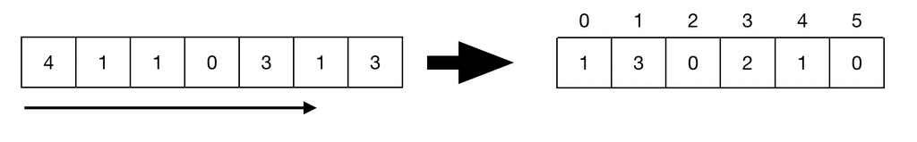

먼저 $A = [4, 1, 1, 0, 3, 1, 3]$ 배열에 있는 자료를 첫 인덱스부터 마지막 인덱스까지 읽으면서 새로운 리스트에 해당하는 값들을 센다.

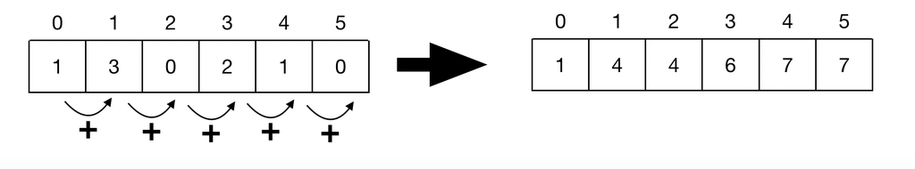

그리고 오른쪽 방향으로 각 인덱스 값을 누적으로 더한다.

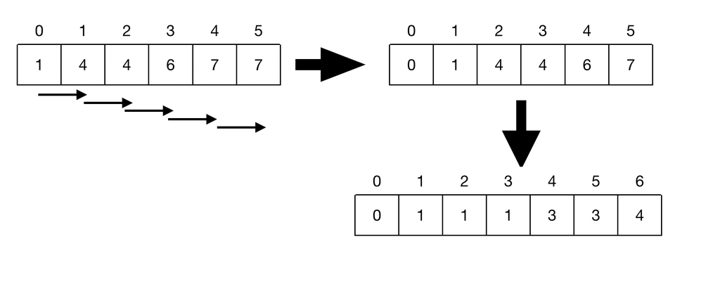

그 다음 1인덱스를 오른쪽 방향으로 이동한 후 인덱스 아래 값들을 인덱스의 시작 위치이다. 예를 들면 위에 그림에서 인덱스 1의 값은 1이고 인덱스 2의 값은 4이다. 즉 새로운 리스트의 인덱스 1부터 $4-1 = 3$는 1의 값을 가진다는 거다. 2번과 3번 인덱스인 경우 값이 똑같으므로 없는 값이다. 그러면 $A = [4, 1, 1, 0, 3, 1, 3]$ 배열은 $A = [0, 1, 1, 1, 3, 3, 4]$ 정렬된 배열이 나온다.